# Project Python Foundations: FoodHub Data Analysis

### **Question 7**: Which are the top 5 restaurants in terms of the number of orders received? [1 mark]

```python
# Write the code here
orders['restaurant_name'].value_counts().head(5)
```

```
Shake Shack                  219
The Meatball Shop            132
Blue Ribbon Sushi            119
Blue Ribbon Fried Chicken     96
Parm                          68
Name: restaurant_name, dtype: int64
```

#### Observations:

Top 5 and the last 5 restaurants ( with least value as 1 order) can be visualized with value_counts().sum. Hence, the top 5 restaurants with more number of orders:

- Shake Shack 219
- The Meatball Shop 132
- Blue Ribbon Sushi 119
- Blue Ribbon Fried Chicken 96
- Parm 68

### **Question 8**: Which is the most popular cuisine on weekends? [1 mark]

```python
# Write the code here
#orders["cuisine_type"].value_counts().sum
orders.loc[orders["day_of_the_week"] == "Weekend", 'cuisine_type'].value_counts()
```

```
American          415
Japanese          335
Italian           207
Chinese           163
Mexican            53
Indian             49
Mediterranean      32
Middle Eastern     32
Thai               15
French             13
Korean             11
Southern           11
Spanish            11
Vietnamese          4
Name: cuisine_type, dtype: int64
```

#### Observations:

- The most popular cuisine on weekends is `American`, offcourse it is popular on all days not only on weekends

### **Question 9**: What percentage of the orders cost more than 20 dollars? [2 marks]

```python
# Write the code here
order_percent_cost_gt_20=(orders.loc[orders['cost_of_the_order'] > 20].shape[0]/orders.shape[0])*100
print("Percentage of the orders cost more than 20 dollars is", round(order_percent_cost_gt_20, 2), "%")
```

```
Percentage of the orders cost more than 20 dollars is 29.24 %
```

#### Observations:

- Percentage of the orders cost more than 20 dollars is 29.24%

### **Question 10**: What is the mean order delivery time? [1 mark]

```python
# Write the code here
print("mean order delivery time is", round(orders['delivery_time'].mean(), 2))
```

```
mean order delivery time is 24.16
```

#### Observations:

- Mean order delivery time is 24.16

### **Question 11:** The company has decided to give 20% discount vouchers to the top 3 most frequent customers. Find the IDs of these customers and the number of orders they placed. [1 mark]

```python
# Write the code here
orders['customer_id'].value_counts().head(3)
```

```
52832    13
47440    10
83287     9
Name: customer_id, dtype: int64
```

#### Observations:

- Top 3 frequent customers who placed the orders with the count are
- customer_id count
- 52832 13
- 47440 10
- 83287 9

### **Question 12**: Perform a multivariate analysis to explore relationships between the important variables in the dataset. (It is a good idea to explore relations between numerical variables as well as relations between numerical and categorical variables) [10 marks]

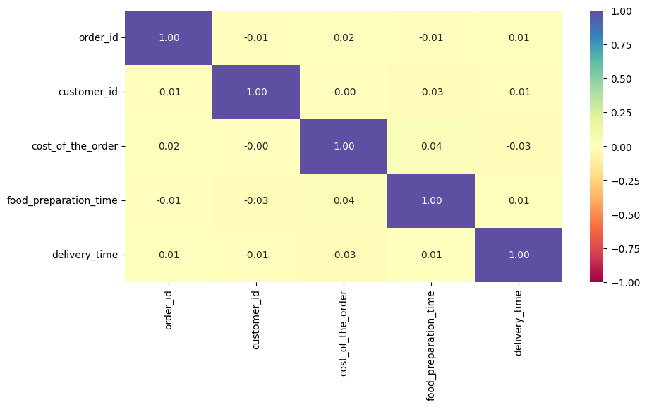

```python
# first find the coorelation between the variables using heapmap - numerical values coorelation
# Plot the heatmap
plt.figure(figsize=(10, 5))
sns.heatmap(orders.corr(), annot=True, vmin=-1, vmax=1, fmt=".2f", cmap="Spectral")
plt.show()

# observations:
# No best coorelation between the cosst_of_the_order, food_preperation_time and delivery_time ( numerical variables)
```